# 基于PaddleHub的疫情期间网民情绪识别

本项目为[疫情期间网民情绪识别比赛](https://www.datafountain.cn/competitions/423)的解决方案。使用了PaddleHub和ERNIE实现对疫情期间微博文本的情绪识别。

## 1. [赛题背景](https://www.datafountain.cn/competitions/423)

新型冠状病毒（COVID-19）感染的肺炎疫情牵动着全国人民的心，全国同舟共济、众志成城，打响了一场没有硝烟的疫情阻击战。习主席指出：要鼓励运用大数据、人工智能、云计算等数字技术，在疫情监测分析、病毒溯源、防控救治、资源调配等方面更好发挥支撑作用。为助力疫情防控和疫情之后的经济社会恢复工作，推动北京市政府数据开放，吸纳大数据产业顶尖社会资源，充分释放专业人才智慧资源，北京市经济和信息化局、中国计算机学会大数据专家委员会联合主办科技战疫·大数据公益挑战赛。

2019新型冠状病毒（2019-nCoV）感染的肺炎疫情发生对人们生活生产的方方面面产生了重要影响，并引发国内舆论的广泛关注，众多网民参与疫情相关话题的讨论。为了帮助政府掌握真实社会舆论情况，科学高效地做好防控宣传和舆情引导工作，本赛题针对疫情相关话题开展网民情绪识别的任务。

## 2. 赛题描述

比赛数据给定了微博ID和微博内容，需要选手设计算法对微博内容进行情绪识别，判断微博内容是积极的、消极的还是中性的。

数据集依据与“新冠肺炎”相关的230个主题关键词进行数据采集，抓取了2020年1月1日—2020年2月20日期间共计100万条微博数据，并对其中10万条数据进行人工标注，标注分为三类，分别为：1（积极），0（中性）和-1（消极）。微博内容包括了文本、图片、视频等内容。本方案选用文本内容进行微博内容的情绪识别。赛题采用Macro-F1值进行评分。

赛题数据来源：https://www.datafountain.cn/competitions/423/datasets

## 3. 数据分析

我们先将挂载的比赛数据集解压出来。

```python
# 解压数据集
!cd data/data22724 && unzip test_dataset.zip
!cd data/data22724 && unzip "train_ dataset.zip"
```

```
Archive:  test_dataset.zip
  inflating: nCov_10k_test.csv
Archive:  train_ dataset.zip
  inflating: nCoV_100k_train.labled.csv
  inflating: nCoV_900k_train.unlabled.csv
```

由于数据采用GB2312编码，因此先将数据读出，转换为utf8编码再重新写入，方便后续pandas库的使用处理。

```python
# 转换编码
def re_encode(path):
    with open(path, 'r', encoding='GB2312', errors='ignore') as file:
        lines = file.readlines()
    with open(path, 'w', encoding='utf-8') as file:
        file.write(''.join(lines))

re_encode('data/data22724/nCov_10k_test.csv')
re_encode('data/data22724/nCoV_100k_train.labled.csv')
```

### 3.1 数据预览

读取数据，查看数据大小、列名，可以看到：

训练集包含十万条数据，测试集包含一万条数据

数据包括了微博id, 微博发布时间, 发布人账号, 微博中文内容, 微博图片, 微博视频, 情感倾向。其中微博中文内容是我们将使用的训练和测试数据，情感倾向为问题标签。

```python
# 读取数据
import pandas as pd
train_labled = pd.read_csv('data/data22724/nCoV_100k_train.labled.csv', engine ='python')
test = pd.read_csv('data/data22724/nCov_10k_test.csv', engine ='python')
```

```python
print(train_labled.shape)
print(test.shape)
print(train_labled.columns)
```

```
(100000, 7)
(10000, 6)
Index(['微博id', '微博发布时间', '发布人账号', '微博中文内容', '微博图片', '微博视频', '情感倾向'], dtype='object')
```

```python
train_labled.head(3)
```

|  | 微博id | 微博发布时间 | 发布人账号 | 微博中文内容 | 微博图片 | 微博视频 | 情感倾向 |
| --- | --- | --- | --- | --- | --- | --- | --- |
| 0 | 4456072029125500 | 01月01日 23:50 | 存曦1988 | 写在年末冬初孩子流感的第五天，我们仍然没有忘记热情拥抱这2020年的第一天。带着一丝迷信，早... | ['https://ww2.sinaimg.cn/orj360/005VnA1zly1gah... | [] | 0 |
| 1 | 4456074167480980 | 01月01日 23:58 | LunaKrys | 开年大模型…累到以为自己发烧了腰疼膝盖疼腿疼胳膊疼脖子疼#Luna的Krystallife#? | [] | [] | -1 |
| 2 | 4456054253264520 | 01月01日 22:39 | 小王爷学辩论o_O | 邱晨这就是我爹，爹，发烧快好，毕竟美好的假期拿来养病不太好，假期还是要好好享受快乐，爹，新年... | ['https://ww2.sinaimg.cn/thumb150/006ymYXKgy1g... | [] | 1 |

```python
test.head(3)
```

|  | 微博id | 微博发布时间 | 发布人账号 | 微博中文内容 | 微博图片 | 微博视频 |
| --- | --- | --- | --- | --- | --- | --- |
| 0 | 4456068992182160 | 01月01日 23:38 | -精@的ii女鹗- | #你好2020#新年第一天元气满满的早起出门买早饭结果高估了自己抗冻能力回家成功冻发烧（大概... | ['https://ww2.sinaimg.cn/thumb150/745aa591ly1g... | [] |
| 1 | 4456424178427250 | 01月02日 23:09 | liujunyi88 | 大宝又感冒鼻塞咳嗽了，还有发烧。队友加班几天不回。感觉自己的情绪在家已然是随时引爆的状态。情... | [] | [] |
| 2 | 4456797466940200 | 01月03日 23:53 | ablsa | 还要去输两天液，这天也太容易感冒发烧了，一定要多喝热水啊? | ['https://ww3.sinaimg.cn/orj360/006fTidCly1gaj... | [] |

### 3.2 标签分布

问题标签分为三类，分别为：1（积极），0（中性）和-1（消极），其分布如下。

可以看到，中性数据数量占一半以上，积极次之，消极最少。

此外，数据中还包含少量的未知标签，我们将其视为异常数据剔除。

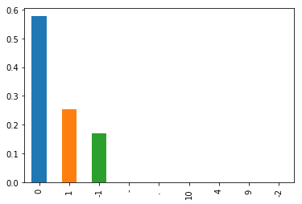

```python
# 标签分布
%matplotlib inline
train_labled['情感倾向'].value_counts(normalize=True).plot(kind='bar');
```

```python
# 清除异常标签数据
train_labled = train_labled[train_labled['情感倾向'].isin(['-1','0','1'])]
```

### 3.3 文本长度

训练集文本长度最大为 241，平均为 87。

```python
train_labled['微博中文内容'].str.len().describe()
```

```
count    99560.000000
mean        87.276416
std         49.355898
min          1.000000
25%         42.000000
50%         86.000000
75%        139.000000
max        241.000000
Name: 微博中文内容, dtype: float64
```

## 4. 方案介绍 —— 用PaddleHub快速入手一场数据比赛

如果只考虑微博文本数据，比赛需要解决的问题其实是文本分类问题。

随着2018年ELMo、BERT等模型的发布，NLP领域进入了“大力出奇迹”的时代。采用大规模语料上进行无监督预训练的深层模型，在下游任务数据上微调一下，即可达到很好的效果。曾经需要反复调参、精心设计结构的任务，现在只需简单地使用更大的预训练数据、更深层的模型便可解决。

因此NLP比赛的入手门槛也随之变低。新手只要选择好预训练模型，在自己数据上微调，很多情况下就可以达到很好的效果。

本项目将采用百度出品的PaddleHub预训练模型微调工具，快速构建比赛方案。模型方面则选择ERNIE模型。

- [ERNIE](https://www.paddlepaddle.org.cn/ernie)

  ERNIE 1.0 通过建模海量数据中的词、实体及实体关系，学习真实世界的语义知识。相较于 BERT 学习原始语言信号，ERNIE 直接对先验语义知识单元进行建模，增强了模型语义表示能力。
- [PaddleHub](https://www.paddlepaddle.org.cn/hub)

  PaddlePaddle 出品的预训练模型管理和迁移学习工具，便捷地获取PaddlePaddle生态下的预训练模型，完成模型的管理和一键预测。配合使用Fine-tune API，可以基于大规模预训练模型快速完成迁移学习，让预训练模型能更好地服务于用户特定场景的应用。

  其使用流程如下：

  1）将数据整理成特定格式

  2）定义Dataset数据类

  3）加载模型

  4）构建reader数据读取接口

  5）确定finetune训练策略

  6）配置finetune参数

  7）确定任务，开始finetune（训练）

  8）预测

  以上流程每个步骤只需一两句代码即可完成，使得我们可以快速得到解决方案。

首先，安装更新PaddleHub

```python
# 更新paddlehub
!pip install --upgrade paddlehub -i https://pypi.tuna.tsinghua.edu.cn/simple
```

### 4.1 数据整理

PaddleHub文本任务的输入数据格式为：

| text | label |
| --- | --- |
| 我想吃雪糕 | 0 |
| ... | ... |

我们将数据划分为训练集和验证集，比例为8：2, 然后保存为文本文件，两列需用tab分隔符隔开。

```python
# 划分验证集，保存格式  text[\t]label
from sklearn.model_selection import train_test_split

train_labled = train_labled[['微博中文内容', '情感倾向']]
train, valid = train_test_split(train_labled, test_size=0.2, random_state=2020)
train.to_csv('/home/aistudio/data/data22724/train.txt', index=False, header=False, sep='\t')
valid.to_csv('/home/aistudio/data/data22724/valid.txt', index=False, header=False, sep='\t')
```

### 4.2 [自定义数据加载](https://github.com/PaddlePaddle/PaddleHub/blob/release/v1.5/docs/tutorial/how_to_load_data.md)

加载文本类自定义数据集，用户仅需要继承基类BaseNLPDatast，修改数据集存放地址以及类别即可。

这里我们没有带标签的测试集，所以test_file直接用验证集代替 "valid.txt" 。

```python
# 自定义数据集
import os
import codecs
import csv

from paddlehub.dataset.base_nlp_dataset import BaseNLPDataset

class MyDataset(BaseNLPDataset):
    """DemoDataset"""
    def __init__(self):
        # 数据集存放位置
        self.dataset_dir = "/home/aistudio/data/data22724"
        super(MyDataset, self).__init__(
            base_path=self.dataset_dir,
            train_file="train.txt",
            dev_file="valid.txt",
            test_file="valid.txt",
            train_file_with_header=False,
            dev_file_with_header=False,
            test_file_with_header=False,
            # 数据集类别集合
            label_list=["-1", "0", "1"])

dataset = MyDataset()
for e in dataset.get_train_examples()[:3]:
    print("{}\t{}\t{}".format(e.guid, e.text_a, e.label))
```

```
0	【#吃中药后新冠肺炎患者紧张心理得到缓解#生病时，你一般吃中药还是西药？】国家中医药管理局医疗救治专家组组长、中国工程院院士、中国中医科学院院长黄璐琦14日介绍，在新冠肺炎患者救治中，老百姓对中医药有种迫切需求，吃了中医药后紧张心理得到一定程度缓解。生病时，你一般吃中药还是西药?	0
1	又是上班的一天今天依然很爱很爱我的宝贝?	1
2	//@淡梦就是爱吐槽:还有患渐冻症不离一线的张定宇，高龄赶赴现场的钟南山、李兰娟，抗击疫病的医生，奋力建医院的工人，危急时赶赴疫区的子弟兵…心存人民的人，无论他是学术泰斗、医生或者什么身份，他们都是希望的灯火。	1
```

### 4.3 加载模型

这里我们选择ERNIE1.0的中文预训练模型。

其他模型见：https://github.com/PaddlePaddle/PaddleHub

只需修改name='xxx' 就可以切换不同的模型

```python
# 加载模型
import paddlehub as hub
module = hub.Module(name="ernie")
```

```
[2020-03-04 23:33:07,191] [    INFO] - Installing ernie module
```

```
Downloading ernie
[==================================================] 100.00%
Uncompress /home/aistudio/.paddlehub/tmp/tmp07v467mj/ernie
[==================================================] 100.00%
```

```
[2020-03-04 23:33:24,583] [    INFO] - Successfully installed ernie-1.1.0
```

### 4.4 构建Reader

构建一个文本分类的reader，reader负责将dataset的数据进行预处理，首先对文本进行切词，接着以特定格式组织并输入给模型进行训练。

通过max_seq_len可以修改最大序列长度，若序列长度不足，会通过padding方式补到max_seq_len, 若序列长度大于该值，则会以截断方式让序列长度为max_seq_len, 这里我们设置为128。

```python
# 构建Reader
reader = hub.reader.ClassifyReader(
    dataset=dataset,
    vocab_path=module.get_vocab_path(),
    sp_model_path=module.get_spm_path(),
    word_dict_path=module.get_word_dict_path(),
    max_seq_len=128)
```

```
[2020-03-04 23:33:25,052] [    INFO] - Dataset label map = {'-1': 0, '0': 1, '1': 2}
```

### 4.5 finetune策略

选择迁移优化策略。详见 Strategy

此处我们设置最大学习率为 learning_rate=5e-5。

权重衰减设置为 weight_decay=0.01，其避免模型overfitting。

训练预热的比例设置为 warmup_proportion=0.1, 这样前10%的训练step中学习率会逐步提升到learning_rate

```python
# finetune策略
strategy = hub.AdamWeightDecayStrategy(
    weight_decay=0.01,
    warmup_proportion=0.1,
    learning_rate=5e-5)
```

### 4.6 运行配置

设置训练时的epoch，batch_size，模型储存路径等参数。

这里我们设置训练轮数 num_epoch = 1，模型保存路径 checkpoint_dir="model"， 每100轮（eval_interval）对验证集验证一次评分，并保存最优模型。

```python
# 运行配置
config = hub.RunConfig(
    use_cuda=True,
    num_epoch=1,
    checkpoint_dir="model",
    batch_size=32,
    eval_interval=100,
    strategy=strategy)
```

```
[2020-03-04 23:33:25,107] [    INFO] - Checkpoint dir: model
```

### 4.7 组建Finetune Task

对于文本分类任务，我们需要获取模型的池化层输出，并在后面接上全连接层实现分类。

因此，我们先获取module的上下文环境，包括输入和输出的变量，并从中获取池化层输出作为文本特征。再接入一个全连接层，生成Task。

比赛评价指标为F1，因此设置metrics_choices=["f1"]

```python
# Finetune Task
inputs, outputs, program = module.context(
    trainable=True, max_seq_len=128)

# Use "pooled_output" for classification tasks on an entire sentence.
pooled_output = outputs["pooled_output"]

feed_list = [
    inputs["input_ids"].name,
    inputs["position_ids"].name,
    inputs["segment_ids"].name,
    inputs["input_mask"].name,
]

cls_task = hub.TextClassifierTask(
        data_reader=reader,
        feature=pooled_output,
        feed_list=feed_list,
        num_classes=dataset.num_labels,
        config=config,
        metrics_choices=["f1"])
```

```
[2020-03-04 23:33:25,195] [    INFO] - Set maximum sequence length of input tensor to 128
[2020-03-04 23:33:25,196] [    INFO] - The shape of input tensor[input_ids] set to [-1, 128, 1]
[2020-03-04 23:33:25,197] [    INFO] - The shape of input tensor[position_ids] set to [-1, 128, 1]
[2020-03-04 23:33:25,197] [    INFO] - The shape of input tensor[segment_ids] set to [-1, 128, 1]
[2020-03-04 23:33:25,197] [    INFO] - The shape of input tensor[input_mask] set to [-1, 128, 1]
[2020-03-04 23:33:25,198] [    INFO] - 199 pretrained paramaters loaded by PaddleHub
```

### 4.8 开始finetune

我们使用finetune_and_eval接口就可以开始模型训练，finetune过程中，会周期性的进行模型效果的评估。

```python
# finetune
run_states = cls_task.finetune_and_eval()
```

```
2020-03-04 23:33:25,879-WARNING: paddle.fluid.layers.py_reader() may be deprecated in the near future. Please use paddle.fluid.io.DataLoader.from_generator() instead.
[2020-03-04 23:33:26,141] [    INFO] - Strategy with scheduler: {'warmup': 0.1, 'linear_decay': {'start_point': 0.1, 'end_learning_rate': 0}, 'noam_decay': False, 'discriminative': {'blocks': 0, 'factor': 2.6}, 'gradual_unfreeze': 0, 'slanted_triangle': {'cut_fraction': 0.0, 'ratio': 32}}, regulariz…
[2020-03-04 23:33:30,272] [    INFO] - Try loading checkpoint from model/ckpt.meta
[2020-03-04 23:33:30,273] [    INFO] - PaddleHub model checkpoint not found, start from scratch...
[2020-03-04 23:33:30,336] [    INFO] - PaddleHub finetune start
[2020-03-04 23:33:33,724] [   TRAIN] - step 10 / 2497: loss=1.64911 f1=0.00000 [step/sec: 2.97]
[2020-03-04 23:33:36,281] [   TRAIN] - step 20 / 2497: loss=1.52376 f1=0.00000 [step/sec: 3.91]
[2020-03-04 23:33:38,836] [   TRAIN] - step 30 / 2497: loss=1.36988 f1=0.06383 [step/sec: 3.92]
[2020-03-04 23:33:41,389] [   TRAIN] - step 40 / 2497: loss=1.16186 f1=0.58088 [step/sec: 3.92]
[2020-03-04 23:33:43,940] [   TRAIN] - step 50 / 2497: loss=0.95184 f1=0.83871 [step/sec: 3.92]
[2020-03-04 23:33:46,492] [   TRAIN] - step 60 / 2497: loss=0.95614 f1=0.85213 [step/sec: 3.92]
[2020-03-04 23:33:49,044] [   TRAIN] - step 70 / 2497: loss=0.91074 f1=0.82038 [step/sec: 3.92]
[2020-03-04 23:33:51,598] [   TRAIN] - step 80 / 2497: loss=0.89246 f1=0.82990 [step/sec: 3.92]
[2020-03-04 23:33:54,147] [   TRAIN] - step 90 / 2497: loss=0.79546 f1=0.88279 [step/sec: 3.93]
[2020-03-04 23:33:56,702] [   TRAIN] - step 100 / 2497: loss=0.76742 f1=0.85799 [step/sec: 3.92]
[2020-03-04 23:33:56,704] [    INFO] - Evaluation on dev dataset start
2020-03-04 23:33:57,421-WARNING: paddle.fluid.layers.py_reader() may be deprecated in the near future. Please use paddle.fluid.io.DataLoader.from_generator() instead.
share_vars_from is set, scope is ignored.
[2020-03-04 23:34:44,714] [    EVAL] - [dev dataset evaluation result] loss=0.74527 f1=0.86713 [step/sec: 13.32]
[2020-03-04 23:34:44,715] [    EVAL] - best model saved to model/best_model [best f1=0.86713]
2020-03-04 23:34:45,346-WARNING: paddle.fluid.layers.py_reader() may be deprecated in the near future. Please use paddle.fluid.io.DataLoader.from_generator() instead.
[2020-03-04 23:34:49,218] [   TRAIN] - step 110 / 2497: loss=0.76640 f1=0.86197 [step/sec: 3.91]
[2020-03-04 23:34:51,780] [   TRAIN] - step 120 / 2497: loss=0.70161 f1=0.83230 [step/sec: 3.91]
[2020-03-04 23:34:54,334] [   TRAIN] - step 130 / 2497: loss=0.71993 f1=0.86905 [step/sec: 3.92]
[2020-03-04 23:34:56,889] [   TRAIN] - step 140 / 2497: loss=0.64350 f1=0.89091 [step/sec: 3.92]
[2020-03-04 23:34:59,435] [   TRAIN] - step 150 / 2497: loss=0.61041 f1=0.89764 [step/sec: 3.93]
[2020-03-04 23:35:01,984] [   TRAIN] - step 160 / 2497: loss=0.65475 f1=0.89136 [step/sec: 3.93]
[2020-03-04 23:35:04,534] [   TRAIN] - step 170 / 2497: loss=0.68193 f1=0.85801 [step/sec: 3.92]
[2020-03-04 23:35:07,086] [   TRAIN] - step 180 / 2497: loss=0.65886 f1=0.90608 [step/sec: 3.92]
[2020-03-04 23:35:09,635] [   TRAIN] - step 190 / 2497: loss=0.65174 f1=0.87869 [step/sec: 3.92]
[2020-03-04 23:35:12,184] [   TRAIN] - step 200 / 2497: loss=0.69672 f1=0.87500 [step/sec: 3.93]
[2020-03-04 23:35:12,185] [    INFO] - Evaluation on dev dataset start
[2020-03-04 23:35:59,019] [    EVAL] - [dev dataset evaluation result] loss=0.63386 f1=0.88068 [step/sec: 13.35]
[2020-03-04 23:35:59,021] [    EVAL] - best model saved to model/best_model [best f1=0.88068]
[2020-03-04 23:36:14,124] [   TRAIN] - step 210 / 2497: loss=0.70780 f1=0.84211 [step/sec: 3.88]
[2020-03-04 23:36:16,682] [   TRAIN] - step 220 / 2497: loss=0.61134 f1=0.91365 [step/sec: 3.91]
[2020-03-04 23:36:19,237] [   TRAIN] - step 230 / 2497: loss=0.64374 f1=0.88825 [step/sec: 3.92]
[2020-03-04 23:36:21,789] [   TRAIN] - step 240 / 2497: loss=0.70095 f1=0.87135 [step/sec: 3.92]
[2020-03-04 23:36:24,343] [   TRAIN] - step 250 / 2497: loss=0.60753 f1=0.90634 [step/sec: 3.92]
[2020-03-04 23:36:26,896] [   TRAIN] - step 260 / 2497: loss=0.66083 f1=0.85621 [step/sec: 3.92]
```

[output cut: 248 more lines]

```
[2020-03-05 00:03:16,929] [   TRAIN] - step 2430 / 2497: loss=0.55817 f1=0.93642 [step/sec: 3.90]
[2020-03-05 00:03:19,492] [   TRAIN] - step 2440 / 2497: loss=0.57317 f1=0.88579 [step/sec: 3.90]
[2020-03-05 00:03:22,052] [   TRAIN] - step 2450 / 2497: loss=0.57964 f1=0.90085 [step/sec: 3.91]
[2020-03-05 00:03:24,615] [   TRAIN] - step 2460 / 2497: loss=0.50023 f1=0.91534 [step/sec: 3.91]
[2020-03-05 00:03:27,187] [   TRAIN] - step 2470 / 2497: loss=0.54946 f1=0.91733 [step/sec: 3.89]
[2020-03-05 00:03:29,749] [   TRAIN] - step 2480 / 2497: loss=0.48350 f1=0.93814 [step/sec: 3.91]
[2020-03-05 00:03:32,308] [   TRAIN] - step 2490 / 2497: loss=0.52125 f1=0.90052 [step/sec: 3.91]
[2020-03-05 00:03:34,310] [    INFO] - Evaluation on dev dataset start
[2020-03-05 00:04:21,206] [    EVAL] - [dev dataset evaluation result] loss=0.54318 f1=0.90342 [step/sec: 13.33]
[2020-03-05 00:04:21,207] [    EVAL] - best model saved to model/best_model [best f1=0.90342]
[2020-03-05 00:04:24,357] [    INFO] - Load the best model from model/best_model
[2020-03-05 00:04:25,028] [    INFO] - Evaluation on test dataset start
[2020-03-05 00:05:11,892] [    EVAL] - [test dataset evaluation result] loss=0.54318 f1=0.90342 [step/sec: 13.34]
[2020-03-05 00:05:11,893] [    INFO] - Saving model checkpoint to model/step_2498
[2020-03-05 00:05:12,878] [    INFO] - PaddleHub finetune finished.
```

### 4.9 预测

finetune完成后，调用predict接口即可完成预测

预测数据格式为二维的list：

[['第一条文本'], ['第二条文本'], [...], ...]

```python
# 预测
import numpy as np

inv_label_map = {val: key for key, val in reader.label_map.items()}

# Data to be prdicted
data = test[['微博中文内容']].fillna(' ').values.tolist()

run_states = cls_task.predict(data=data)
results = [run_state.run_results for run_state in run_states]
```

```
[2020-03-05 00:05:12,900] [    INFO] - The best model has been loaded
[2020-03-05 00:05:12,901] [    INFO] - PaddleHub predict start
share_vars_from is set, scope is ignored.
[2020-03-05 00:05:36,348] [    INFO] - PaddleHub predict finished.
```

### 4.10 生成结果

```python
# 生成预测结果
proba = np.vstack([r[0] for r in results])
prediction = list(np.argmax(proba, axis=1))
prediction = [inv_label_map[p] for p in prediction]

submission = pd.DataFrame()
submission['id'] = test['微博id'].values
submission['id'] = submission['id'].astype(str) + ' '
submission['y'] = prediction
np.save('proba.npy', proba)
submission.to_csv('result.csv', index=False)
submission.head()
```

|  | id | y |
| --- | --- | --- |
| 0 | 4456068992182160 | 0 |
| 1 | 4456424178427250 | -1 |
| 2 | 4456797466940200 | 0 |
| 3 | 4456791021108920 | -1 |
| 4 | 4457086404997440 | -1 |

让我们来看看具体预测结果。

```python
submission['text'] = test[['微博中文内容']].fillna(' ').values
submission['label'] = submission['y'].map({-1: '消极', 0: '中性', 1: '积极'})
display(submission[['text', 'label']][176:181])
```

|  | text | label |
| --- | --- | --- |
| 176 | //@派大蛋://@春光灿烂桔八戒:扩//@展台手册:看看汉口医院看看汉口医院因为是小医院所... | 中性 |
| 177 | #内蒙古急寻和患者同超市购物及同乘人员#【急转扩散！#内蒙古急寻和患者同超市购物及同乘人员#... | 中性 |
| 178 | 今天终于吃到钱了！！！为什么不禁放啊大初一早晨都不能自然醒睡到十点多躺到十一点半回姥姥家吃午... | 中性 |
| 179 | //@阿舍的后草园:看到连央-视-新-闻都在学澎湃之流搞截图式抢爆点新闻，就觉得失望又恶心。... | 消极 |
| 180 | 希望接下来全是好消息??//@紫光阁:【更多好消息！还有4名医护人员新型冠状病毒核酸检测也转... | 积极 |

可以看到网民情绪可以被模型成功识别。最后提交结果的线上分数为 F1 = 0.7128。

## 5. 总结

本项目使用了PaddleHub完成了疫情期间网民情绪识别比赛方案的快速构建, 并得到了不错的识别效果。

疫情之下，掌握真实社会舆论情况，才能科学地做好防控宣传和舆情引导工作，AI技术可以帮助我们高效地完成识别。

而对于深度学习比赛本身而言，使用预训练模型来加速训练已经是不可避免的步骤了。PaddleHub包含了大量的预训练模型。不管是NLP还是CV类的比赛，我们都可以使用PaddleHub来实现我们的baseline，不需要繁琐的代码，就可以快速切换不同模型来进行实验效果验证。